# 《案例研究方法：理论与范例》导读

曹太鑫

2019年1月15日

# 0 本书的章节结构

- 一共包含两部分，共14章。
- 第一部分包括3章。从介绍案例研究方法入手，着重阐述案例研究方法的策略和步骤，以及如何通过案例研究创建理论。
- 第二部分包括11章。研究领域包括管理决策、组织变革、创业、联盟与并购以及组织学习等。

# 1 第一章：由案例构建理论

- 本文描述了运用案例研究构建理论的全过程——从确定研究问题到得到结论。
- 整个过程是高度迭代的，并且与数据密不可分。
- 这种方法尤其适用于新的研究领域，所得到的理论往往更具新意、可检验，并且具有实证效度。
- 评估这类研究的关键指标包括突破常理的独到见解、具有良好理论品质（简洁和逻辑一致等）和令人信服的实证根基
- Glaser 和 Strauss（1967）强调，只有保持于实证数据的紧密联系，才能构建出经得起检验、有意义而且有效的理论。
- 案例研究存在的问题：
  - 定性数据、归纳逻辑和案例研究方法
  - 由案例研究构建理论到底是怎样的过程，特别是处于核心地位的归纳过程以及文献的作用。

## 1.1运用案例研究构建理论的路径图

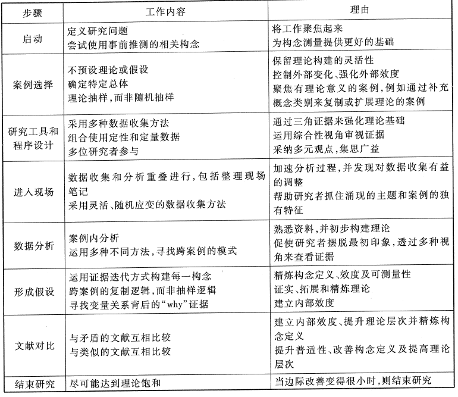

# 2 案例研究方法的背景

- Glaser 和Strauss（1967）提出的扎根理论。在研究过程中要不断进行比较，强调理论的分类要完全来自于证据，以及渐进式的进行案例选择和数据收集
- Yin（1981，1984）描述了案例研究设计方法。将其看成一种研究策略。强调将实验研究设计中所关心的信度和效度引入到案例研究设计中。
- Miles 和 Huberman （1984）开发了定性数据分析运用的具体技术。如图表，精细编码等
- “总是故意唱反调者”的方法（resident devil‘s advocate）、三角调查方法、跨案例分析方法、民族志、三角数据类型、直接观察研究等

# 3 案例研究方法

- 案例研究是一种研究策略，其焦点在于理解某种单一情景下的动态过程。
- 案例研究可以是单案例也可以是多案例，并且具有多个层次
- 案例研究一般会运用多种数据收集方法，如文档资料、访谈、问卷调查和实地考察。
- 数据可以是定性的，也可以是定量的，或者两者兼有。
- 用来实现不同的研究目标，包括提供描述、检验理论、或者构建理论。
- 本书侧重于由案例构建理论
- 但是我们侧重于案例研究方法的实现过程，即重点在于案例研究的规范步骤或者通常的做法——**我们的学习目标**

# 4 启动

- 研究问题的初始定义对于案例研究构建理论非常关键 *不管我们的样本有多小，也不管我们关注什么，我们总是尽量带着明确的问题焦点深入组织中，以便系统的收集特定种类的数据。（Mintzberg，1979）*
- 根据推测事先确定一些构念也有助于形成理论构建的最初研究设计，这能帮助我们在研究过程中更加精确地测量构念。
- 试验性。任何构念都不一定会被保留到最后的理论中，不管他们如何被精确的测量了。
- 理论构建研究应该尽可能在没有任何构思中的理论和有待检验的假设的理想情况下展开。

# 5 案例选择

- 恰当的选择总体能控制外部变化，并有助于限定研究发现的适用范围。
- 案例研究采用理论抽样的方法，即所选的案例是基于理论的需要。
- 所选的案例要能复制先前案例的发现，或者能拓展新兴的理论，或者为了填补理论的分类和为两种截然不同的分类提供实例。

# 6 研究工具和程序的设计

- 综合运用多种数据收集方法，访谈、观察、文档资料、定量实验等，基于多种数据收集方法的三角测量使得构念和假设具有更坚实的实证依据。
- 定量数据有助于揭示一些不易被研究者察觉的关系，避免定性数据中那些生动形象但错误的表象所迷惑
- 定性数据擅长揭示那些由定量数据揭示的背后的基本原理，或者提出理论命题然后通过定量数据检验
- 组建多成员的研究团队。一是提高了研究的创造性潜力。二是增强结论的可信度以及发现新理论的可行性

# 7 进入现场

- 运用案例构建理论的一个显著特点就是数据收集和数据分析常常重叠进行。
- 现场笔记：写下现场所发生的一切，而不是挑选我们所认为重要的事物；通过提出问题深化对现场记录的思考。
- 在研究过程中变更甚至增加数据收集方法合理吗？ *根据需要调整数据收集工具、数据收集及分析过程，前提是能使理论的根基更扎实或者提供新的理论视角*

# 8 数据分析

## 8.1 案例内数据分析

- 数据分析的黑箱
- 令人难以置信的海量数据
- 案例内数据分析通常包括针对每个案例的详细描述。
- 总的来说，将每个案例看成单独的个体，然后细致入微的熟悉它们。这样在寻找到跨案例的普适性模式之前，使每个案例独有的模式涌现出来。

## 8.2 寻找跨案例模式

- 跨案例比较的关键就是从多种不同的途径来分析数据，以克服信息处理中的偏差。
- 第一种方法：先选定一些类别或者纬度，然后寻找组内的相似点和组间的不同点
- 第二种方法：就是将案例配对，然后列出每对案例之间的相似点和不同点，这促使研究者寻找案例之间细微的相似和不同之处。
- 第三种方法：按照数据来源将数据分开。有利于从不同的数据收集途径得到独到的见解。
- 总的来说，使用结构化和多样化的视角来分析数据。理论与数据使严格匹配的。

# 9 形成假设

- 研究者要不断的比较理论与数据，在反复的比较中趋近于数据高度吻合的理论。
- 第一步：完善构念的定义，建立证据以在每个案例中度量该构念。数据和构念的之间的不断比较 -这个过程类似于假设检验中多指标来建立对某个构念的测量。确保构念的效度。 *区别：构念的定义与测量是数据分析中形成的，而不是逻辑研究出来的。并且很少能通过多个指标汇总成为某个构念的测量指标。*
- 第二步是验证构念间的关系是否与各案例中的证据相符。每个假设由每个案例分别验证，而不是合并所有案例来验证
  - 通过案例反复验证变量间的关系以提升其效度的可信性
  - 定性数据对于理解变量间的关系为何成立或者不成立特别有帮助。
- 总体来说，形成假设通常包括构念的测量和关系的验证。这与传统假设检验相似，但更具有主观判断色彩，必须判断案例内分析和跨案例分析所的关系强度和一致性。并且在发表研究成果时，要全面展示证据和研究过程，以便读者用他们自己的标准作出判断

# 10 与文献对话

- 将形成的概念、理论或假设同现有文献进行比较，包括相同之处、矛盾之处，以及原因是什么
- 重要性有两点：一是如果忽略了与现有文献相矛盾的发现，那么研究结果的可信度将降低；二是与现有文献冲突意味着机会
- 讨论与研究发现相似的文献同样重要，因为能将那些通常互不相干的现象通过内在的相似性来联系起来。
- 有助于提高由案例研究构建理论的内部效度、普适性和理论水平

# 11 结束研究

- 两个问题：一是何时停止增加案例；二是何时结束理论和数据的反复比较。
- 第一个问题：当理论达到饱和时研究者应该停止增加新的案例
  - 一般案例在4到10个左右效果不错：少于4个案例，难以产生复杂的理论；多于10个案例，其复杂性和海量数据常常难以应对。
- 第二个问题：核心判断标准依然是理论饱和度

# 12 由案例构建理论的优势

- 具有产生新颖理论的潜质。努力调解来自跨案例、各种数据和不同研究者的证据，以及案例与已有文献的对比，增加在新理论视角下产生创新性框架的可能性
- 案例研究形成的理论较可能是可检验的，其构念可直接测量而其假设可被证伪。
- 所获得的理论可能具备实证效度，而且这种可能性很高，因为理论构建过程与证据密切关联，因此所获得的结论也极有可能与实证观察一致

# 13 由案例构建理论的劣势

- 深度使用实证证据会产生过于复杂的理论。
- 由案例构建的理论可能会是狭隘和特殊的理论。非常特殊的现象或者研究者无法提升理论的普适性水平

# 14 适用性

- 案例研究适用于研究的早期阶段，或是对一个已有的研究主题提供新鲜的视角
- 构建理论的过程是基于以往文献和实证观察或经验，也依赖于研究者的洞察力，从而构建出更具有说服力的理论。
- 当现有理论贫瘠乏力的时候，由案例研究构建理论的过程所蕴含的内在矛盾较可能产生新颖理论的产生。

# 15 评估

- 没有公认的一般性指导标准来评估这种类型的研究，但仍有几条适用的标准
  - 研究过程中产生的构念、框架或命题是否是“好的理论”。好的理论应该是简介、可检验和逻辑一致的。
  - 严格的方法和理论扎根于证据。应该提供关于样本、数据收集过程和分析的说明信息，也应该为每个构念展示足够的证据，以使读者能够自己评估理论是否于证据相符。
  - 好的理论研究应该产生新的深刻见解。目标是新的理论，好的理论构建应能产生新的、也许是打破框架的真知灼见。